# 2022-04-26 Math 472/572 Statistical Inference

## Hypothesis Test on a Population Proportion, Sampling Distribution is Normal

As with our confidence interval on a population proportion (the proportion of NC residents that believe marijuana should be legalized for recreational use), since our sampling distribution was assumed to be normal (we passed our two checks), we can use formulas to conduct a hypothesis test.

## Hypothesis Test on a Population Proportion, Using Bootstrapping

Back to our Medical Consultant Example: People providing an organ for donation sometimes seek the help of a special “medical consultant.” These consultants assist the patient in all aspects of the surgery, with the goal of reducing the possibility of complications during the medical procedure and recovery. Patients might choose a consultant based in part on the historical complication rate of the consultant’s clients. One consultant tried to attract patients by noting the average complication rate for liver donor surgeries in the US is about 10%, but her clients have only had 3 complications in the 62 liver donor surgeries she has facilitated. She claims this is strong evidence that her work meaningfully contributes to reducing complications (and therefore she should be hired!).

We want to find if the low complication rate of $\hat{p} = 0.048 = 3/62$ could have simply occurred by chance, if her complication rate does not differ from the US standard rate?.

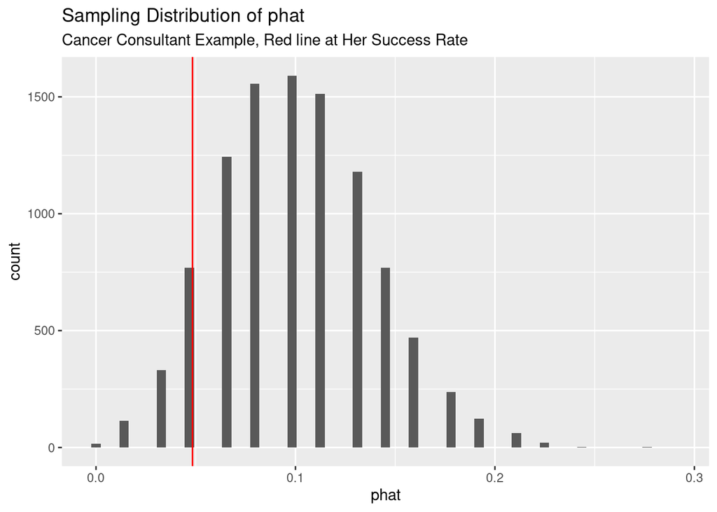

```r
#  Define our population with 10% chance of success, 1
sample_space <- c(1, rep(0,9))  # 1 is a success, 0 is a failure

phat_vals <- vector("double", length = 10000)

for (i in 1:10000){
  s <- sample(sample_space,62,replace = TRUE)
  phat_vals[i] <- sum(s)/length(s)
}

sampling_dist <- tibble( phat = phat_vals)

ggplot(sampling_dist) + geom_histogram(aes(x = phat),bins = 63) + geom_vline(xintercept = phat_consult, color = 'red') +
  labs(title = "Sampling Distribution of phat",
       subtitle = "Cancer Consultant Example, Red line at Her Success Rate")
```

```r
pvalue <- sampling_dist %>% filter(phat < phat_consult) %>% summarize(left_tail_area = n()/10000)

cat("The probability of getting a proportion of success less than the consultants", phat_consult, "success rate if the population success rate is 10% is", pvalue[[1]])
```

```
## The probability of getting a proportion of success less than the consultants 0.0483871 success rate if the population success rate is 10% is 0.0462
```

Example: A Survey USA poll conducted in Seattle, WA in May 2021 reports that of the 650 respondents (adults living in this area), 159 support proposals to defund police departments https://www.surveyusa.com/client/PollReport.aspx?g=aee4e2ed-504a-4d1c-b24b-0a7e21ad11ad. (See also https://openintro-ims.netlify.app/inference-one-prop.html#one-prop-null-boot)

Here, our sample statistic is the proportion of the population that “support proposals to defund police departments”, or $\hat{p} = 159/650 \approx 0.2446$.

A journalist writing a news story on the poll results wants to use the headline “More than 1 in 5 adults living in Seattle support proposals to defund police departments.” You caution the journalist that they should first conduct a hypothesis test to see if the poll data provide convincing evidence for this claim. Write the hypotheses for this test.